# cdata Transforms

Win-Vector LLC

12/26/2017

Start up and show original `Keras` plot.

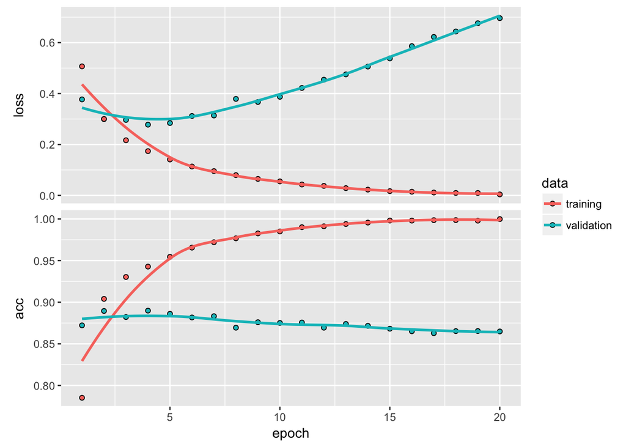

```r
library("ggplot2")
library("cdata")
library("seplyr")
library("keras")
library("kableExtra")
options(knitr.table.format = "html")

h <- readRDS("historyobject.rds")
plot(h)
```

```r
dOrig <- readRDS("metricsframe.rds")
dOrig$epoch <- seq_len(nrow(dOrig))


d <- dOrig
d$loss <- -d$loss
d$val_loss <- -d$val_loss
cR <- d %.>%
  head(.)
cR %.>%
  knitr::kable(.) %.>%
  kable_styling(., full_width = F) %.>%
  row_spec(., 0:nrow(cR), background = "lightgrey")
```

| val_loss | val_acc | loss | acc | epoch |
| --- | --- | --- | --- | --- |
| -0.3769818 | 0.8722 | -0.5067290 | 0.7852000 | 1 |
| -0.2996994 | 0.8895 | -0.3002033 | 0.9040000 | 2 |
| -0.2963943 | 0.8822 | -0.2165675 | 0.9303333 | 3 |
| -0.2779052 | 0.8899 | -0.1738829 | 0.9428000 | 4 |
| -0.2842501 | 0.8861 | -0.1410933 | 0.9545333 | 5 |
| -0.3119754 | 0.8817 | -0.1135626 | 0.9656000 | 6 |

Or with a bit more color:

```r
cR %.>%
  knitr::kable(.) %.>%
  kable_styling(., full_width = F) %.>%
  row_spec(., 0:nrow(cR), background = "lightgrey") %.>%
  row_spec(., 0, background = "lightgreen") %.>%
  column_spec(., 1:4, background = "yellow")
```

| val_loss | val_acc | loss | acc | epoch |
| --- | --- | --- | --- | --- |
| -0.3769818 | 0.8722 | -0.5067290 | 0.7852000 | 1 |
| -0.2996994 | 0.8895 | -0.3002033 | 0.9040000 | 2 |
| -0.2963943 | 0.8822 | -0.2165675 | 0.9303333 | 3 |
| -0.2779052 | 0.8899 | -0.1738829 | 0.9428000 | 4 |
| -0.2842501 | 0.8861 | -0.1410933 | 0.9545333 | 5 |
| -0.3119754 | 0.8817 | -0.1135626 | 0.9656000 | 6 |

# Reproducing the first plot

First plot: reproduce the original with bulk-renaming of columns (via the new [`cdata::map_fieldsD()`](https://winvector.github.io/cdata/reference/map_fieldsD.html) function).

First we perform the equivalent of a “shred”, “un-pivot”, or “gather”:

```r
cT <- build_unpivot_control(
  nameForNewKeyColumn= 'origColName',
  nameForNewValueColumn= 'performance',
  columnsToTakeFrom= c('val_loss',
                       'val_acc',
                       'loss',
                       'acc' ))
dT <- rowrecs_to_blocks(
  d,
  controlTable = cT,
  columnsToCopy = "epoch")
cR <- dT %.>%
  head(.)
cR %.>%
  knitr::kable(.) %.>%
  kable_styling(., full_width = F) %.>%
  row_spec(., 0:nrow(cR), background = "lightgrey")
```

| epoch | origColName | performance |
| --- | --- | --- |
| 1 | val_loss | -0.3769818 |
| 1 | val_acc | 0.8722000 |
| 1 | loss | -0.5067290 |
| 1 | acc | 0.7852000 |
| 2 | val_loss | -0.2996994 |
| 2 | val_acc | 0.8895000 |

Then we define a value mapping table to build the new value key columns that we need.

```r
mp <- data.frame(
  origColName = qc(val_loss, val_acc,
                     loss, acc),
  dataset = qc("validation", "validation",
               "training", "training"),
  measure = qc("minus binary cross entropy", "accuracy",
               "minus binary cross entropy", "accuracy"),
  stringsAsFactors = FALSE)
mp %.>%
  knitr::kable(.) %.>%
  kable_styling(., full_width = F)  %.>%
  row_spec(., 0:nrow(mp), background = "lightgrey") %.>%
  column_spec(., 1, background = "lightgreen") %.>%
  column_spec(., 2:ncol(mp), background = "yellow")
```

| origColName | dataset | measure |
| --- | --- | --- |
| val_loss | validation | minus binary cross entropy |
| val_acc | validation | accuracy |
| loss | training | minus binary cross entropy |
| acc | training | accuracy |

We apply that key map and we are ready to plot:

```r
dT <- map_fields(dT,
                 "origColName",
                 mp)
dT$measure <- factor(dT$measure,
                     levels = c("minus binary cross entropy",
                                "accuracy"))
cR <- dT %.>%
  head(.)
cR %.>%
  knitr::kable(.) %.>%
  kable_styling(., full_width = F)  %.>%
  row_spec(., 0:nrow(cR), background = "lightgrey") %.>%
  column_spec(., 2, background = "lightgreen") %.>%
  column_spec(., c(4,5), background = "yellow")
```

| epoch | origColName | performance | dataset | measure |
| --- | --- | --- | --- | --- |
| 1 | val_loss | -0.3769818 | validation | minus binary cross entropy |
| 1 | val_acc | 0.8722000 | validation | accuracy |
| 1 | loss | -0.5067290 | training | minus binary cross entropy |
| 1 | acc | 0.7852000 | training | accuracy |
| 2 | val_loss | -0.2996994 | validation | minus binary cross entropy |
| 2 | val_acc | 0.8895000 | validation | accuracy |

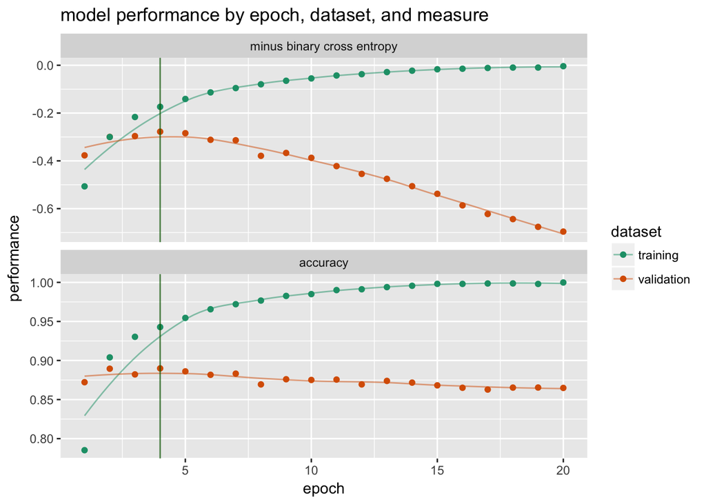

```r
pick <- dT %.>%
  filter_se(.,
            qe(measure == "minus binary cross entropy",
               dataset == "validation")) %.>%
  .$epoch[[which.max(.$performance)]]

ggplot(data = dT,
       aes(x = epoch,
           y = performance,
           color = dataset)) +
  geom_point() +
  stat_smooth(geom = "line", se = FALSE, method = "loess", alpha = 0.5) +
  facet_wrap(~measure, ncol=1, scales = "free_y") +
  geom_vline(xintercept = pick, alpha=0.7, color='darkgreen') +
  scale_color_brewer(palette = "Dark2") +
  ggtitle("model performance by epoch, dataset, and measure")
```

# Creating an improved performance trajectory plot

Second plot: the steps to get to [WVPlots::plot_Keras_fit_trajectory()](https://winvector.github.io/WVPlots/reference/plot_Keras_fit_trajectory.html). In particular show the structure of the control table (especially when applied to itself). The idea is: any in-table block-structure can be taken to any block-structure by moving through a very wide column as an intermediate (or dual form: through a very thin intermediate structure such as RDF-triples).

First let’s take a look at our data.

```r
cR <- d %.>%
  head(.) %.>%
  select_se(., qc(epoch, val_loss, val_acc, loss, acc))
cR %.>%
  knitr::kable(.)  %.>%
  kable_styling(., full_width = F) %.>%
  row_spec(., 0:nrow(cR), background = "lightgrey") %.>%
  column_spec(., 2:5, background = "yellow") %.>%
  row_spec(., 2:nrow(cR), background = "lightgrey")
```

| epoch | val_loss | val_acc | loss | acc |
| --- | --- | --- | --- | --- |
| 1 | -0.3769818 | 0.8722 | -0.5067290 | 0.7852000 |
| 2 | -0.2996994 | 0.8895 | -0.3002033 | 0.9040000 |
| 3 | -0.2963943 | 0.8822 | -0.2165675 | 0.9303333 |
| 4 | -0.2779052 | 0.8899 | -0.1738829 | 0.9428000 |
| 5 | -0.2842501 | 0.8861 | -0.1410933 | 0.9545333 |
| 6 | -0.3119754 | 0.8817 | -0.1135626 | 0.9656000 |

Let’s concentrate on a single row (in this case the first row).

```r
d %.>%
  head(., n=1) %.>%
  select_se(., qc(epoch, val_loss, val_acc, loss, acc)) %.>%
  knitr::kable(.)  %.>%
  kable_styling(., full_width = F) %.>%
  row_spec(., 0:1, background = "lightgrey") %.>%
  column_spec(., 2:5, background = "yellow")
```

| epoch | val_loss | val_acc | loss | acc |
| --- | --- | --- | --- | --- |
| 1 | -0.3769818 | 0.8722 | -0.506729 | 0.7852 |

To create `ggplot2::geom_ribbon()` and `ggplot2::geom_segment()` we need both the training and validation loss for a given epoch to be in the same row. We also want the different performance metrics to be in different rows so we can use `ggplot2::facet_wrap()`. That means we want the first row of data to look like the following sub-table:

```r
cT <- dplyr::tribble(
  ~measure,                 ~training, ~validation,
  "minus binary cross entropy", "loss",    "val_loss",
  "accuracy",               "acc",     "val_acc"
)

cR <- d %.>%
  head(., n=1) %.>%
  rowrecs_to_blocks(
    .,
    controlTable = cT,
    columnsToCopy = "epoch")
cR %.>%
  knitr::kable(.) %.>%
  kable_styling(., full_width = F) %.>%
  row_spec(., 0:nrow(cR), background = "lightgrey") %.>%
  column_spec(., 2, background = "lightgreen") %.>%
  column_spec(., 3:4, background = "yellow")
```

| epoch | measure | training | validation |
| --- | --- | --- | --- |
| 1 | minus binary cross entropy | -0.506729 | -0.3769818 |
| 1 | accuracy | 0.785200 | 0.8722000 |

What allows this motion is the `controlTable` which is essentially a before or after diagram of the transform (depending on which direction you are going). I can not emphasize enough the benefit of looking at the data and drawing out the transform on paper *before* attempting any coding.

The control table is as follows:

```r
cT %.>%
  knitr::kable(.) %.>%
  kable_styling(., full_width = F) %.>%
  row_spec(., 0:nrow(cT), background = "lightgrey") %.>%
  column_spec(., 1, background = "lightgreen") %.>%
  column_spec(., 2:3, background = "yellow")
```

| measure | training | validation |
| --- | --- | --- |
| minus binary cross entropy | loss | val_loss |
| accuracy | acc | val_acc |

It can be applied to data, or to itself, in a forward or backward direction (depending if we use `cdata::rowrecs_to_blocks()` or `cdata::blocks_to_rowrecs()`).

```r
cR <- cT %.>%
  blocks_to_rowrecs(
    .,
    controlTable = cT,
    keyColumns = NULL) %.>%
  select_se(.,
            qc(val_loss, val_acc, loss, acc))
cR %.>%
  knitr::kable(.) %.>%
  kable_styling(., full_width = F) %.>%
  row_spec(., 0:nrow(cR), background = "lightgrey") %.>%
  column_spec(., 1:4, background = "yellow")
```

| val_loss | val_acc | loss | acc |
| --- | --- | --- | --- |
| val_loss | val_acc | loss | acc |

We can now apply the transform to all the data, and produce the final plot.

```r
dT <- rowrecs_to_blocks(
  d,
  controlTable = cT,
  columnsToCopy = "epoch")

cR <- dT %.>%
  head(.)
cR %.>%
  knitr::kable(.) %.>%
  kable_styling(., full_width = F) %.>%
  kable_styling(., full_width = F) %.>%
  row_spec(., 0:nrow(cR), background = "lightgrey") %.>%
  column_spec(., 2, background = "lightgreen") %.>%
  column_spec(., 3:4, background = "yellow")
```

| epoch | measure | training | validation |
| --- | --- | --- | --- |
| 1 | minus binary cross entropy | -0.5067290 | -0.3769818 |
| 1 | accuracy | 0.7852000 | 0.8722000 |
| 2 | minus binary cross entropy | -0.3002033 | -0.2996994 |
| 2 | accuracy | 0.9040000 | 0.8895000 |
| 3 | minus binary cross entropy | -0.2165675 | -0.2963943 |
| 3 | accuracy | 0.9303333 | 0.8822000 |

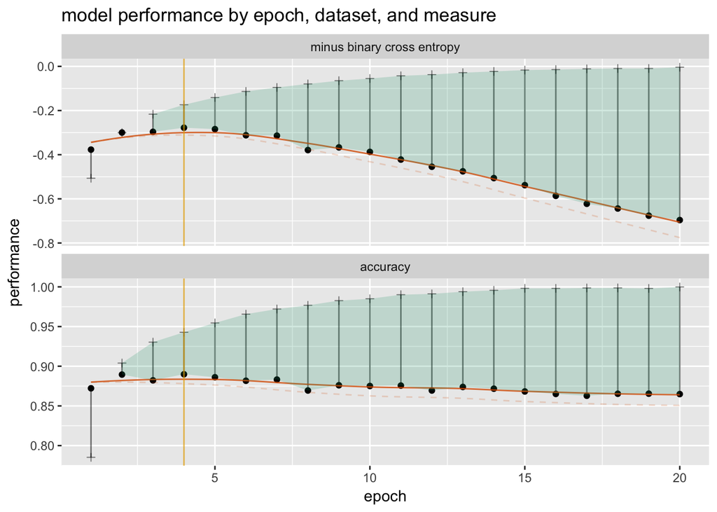

```r
dT$measure <- factor(dT$measure,
                     levels = c("minus binary cross entropy",
                                "accuracy"))

# note: this step requres wrapr 1.0.3 or better
dT <- dT %.>%
  mutate_se(.,
            qae(rmin := ifelse(validation <= training, validation, NA),
                rmax := ifelse(validation <= training, training, NA),
                discounted := ifelse(validation <= training,
                                     validation - 0.1*(training-validation),
                                     validation)))

pick <- dT %.>%
  filter_se(.,
            qe(measure == "minus binary cross entropy")) %.>%
  .$epoch[[which.max(.$discounted)]]

ggplot(data = dT,
       aes(x = epoch,
           xend = epoch,
           y = validation,
           yend = training,
           ymin = rmin,
           ymax = rmax)) +
  geom_segment(alpha = 0.5) +
  geom_point() +
  geom_point(aes(y = training), shape = 3, alpha = 0.5) +
  stat_smooth(geom = "line",
              se = FALSE,
              color  = "#d95f02",
              alpha = 0.8,
              method = "loess") +
  stat_smooth(geom = "line",
              aes(y = discounted),
              se = FALSE,
              color  = "#d95f02",
              alpha = 0.2,
              method = "loess",
              linetype = 2) +
  geom_ribbon(alpha=0.2, fill = "#1b9e77") +
  geom_vline(xintercept = pick, alpha=0.7, color='#e6ab02') +
  facet_wrap(~measure, ncol=1, scales = 'free_y') +
  ylab("performance") +
  ggtitle("model performance by epoch, dataset, and measure")
```

All of the above is now wrapped in convenient function: [WVPlots::plot_Keras_fit_trajectory()](https://winvector.github.io/WVPlots/reference/plot_Keras_fit_trajectory.html).

# Conclusion

All of the above is based on the second generation fluid data theory behind the `cdata` package. The [first generation of the theory](http://winvector.github.io/FluidData/RowsAndColumns.html) was about establishing and maintaining invariant that make data transform reversible and commutative. The [second generation of the theory](http://winvector.github.io/FluidData/ArbitraryTransform.html) is about transforms beyond pivot/un-pivot (moving sets of values in unison).

A quick list of references:

- [Coordinatized Data: A Fluid Data Specification](http://winvector.github.io/FluidData/RowsAndColumns.html)
- [Arbitrary Data Transforms Using cdata](http://winvector.github.io/FluidData/ArbitraryTransform.html)
- [Data Wrangling at Scale](http://winvector.github.io/FluidData/DataWranglingAtScale.html)
- [Big Data Transforms](http://winvector.github.io/FluidData/BigDataTransforms.html)
- [cdata Transforms](http://winvector.github.io/FluidData/PlotExample/PlotExample.html) (*this article*)
- [Plotting Keras Performance Trajectories](http://winvector.github.io/FluidData/PlotExample/KerasPerfPlot.html)
- [Plotting xgboost Performance Trajectories](http://winvector.github.io/FluidData/PlotExample/xgboostPerfPlot.html)